# Preliminary_Analysis

Callen

9/11/2020

## Libraries

```r
library(ggplot2)
library(multcomp)
library(tidyverse)
library(broom)
library(tidyverse)
library(gridExtra)
library(chron)
# The package I normally use for time series, TSA, got discontinued
# from the CRAN repo. Rather than dealing with archives
# and possible versioning issues, I'm currently using a set of libraries that
# do the same thing
library(fable)
library(forecast)
```

## Core Functions

```r
#
```

## Bike

```r
# Read in files
bikeByDay <- read.csv("./data/bike/day.csv")
bikeByDayAndHour <- read.csv("./data/bike/hour.csv")
```

### Basic Plots

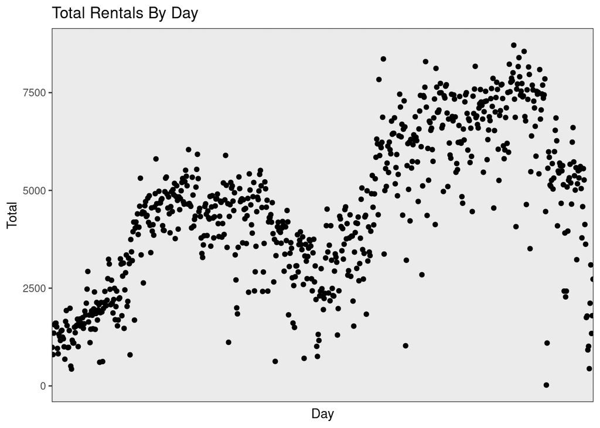

```r
# just a time plot, regardless of other factors
DayDate<-as.Date(bikeByDay$dteday)
bikeByDayPlot<-ggplot(bikeByDay, aes(x=dteday, y=cnt)) +
  geom_point() + theme_bw() + labs(title="Total Rentals By Day", y="Total", x="Day") + theme(axis.text.x=element_blank(), axis.ticks.x=element_blank())
bikeByDayPlot
```

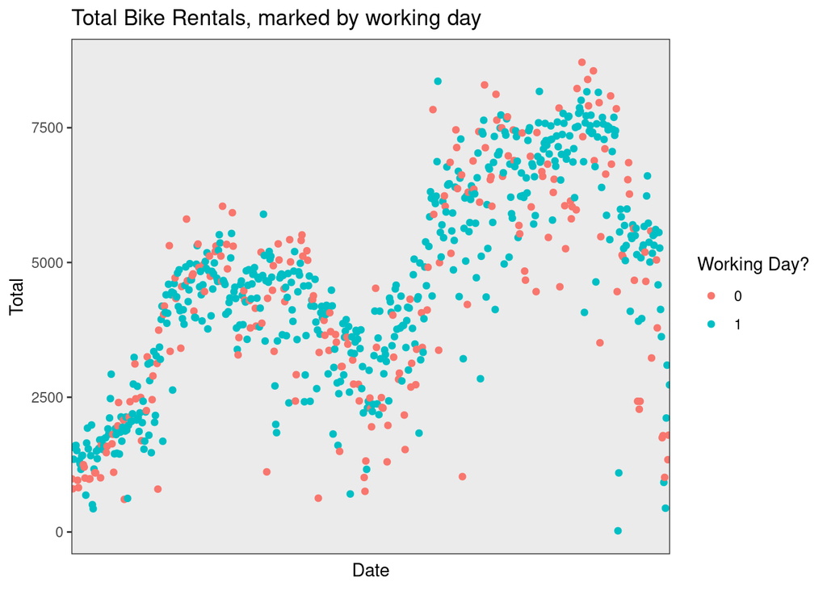

```r
# just a time plot, marked by if it's a work day
# need to change the type of the workingday column, integer
# (meant as boolean) into factor
bikeByDay$workingday<-as.factor(bikeByDay$workingday)
ggplot(bikeByDay, aes(x=dteday, y=cnt, col=workingday)) +
  geom_point() +
  theme_bw() +
  theme(axis.text.x=element_blank(), axis.ticks.x=element_blank()) +
  labs(title="Total Bike Rentals, marked by working day",
       x="Date", y="Total", col="Working Day?")
```

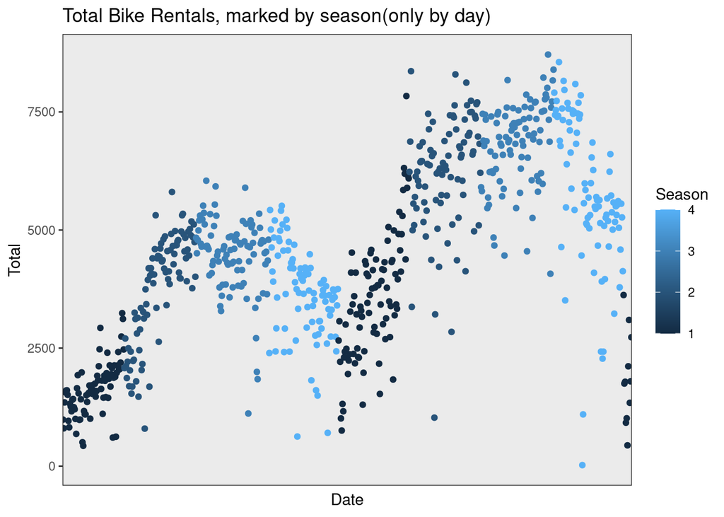

```r
# Seasonal rental
# could isolate the seasons and model those if you want?
# But seasonal structure wouldn't be bad to do forecasting on
ggplot(bikeByDay, aes(x=dteday, y=cnt, col=season)) +
  geom_point() +
  theme_bw() +
  theme(axis.text.x=element_blank(), axis.ticks.x=element_blank()) +
  labs(title="Total Bike Rentals, marked by season(only by day)",
       x="Date", y="Total", col="Season")
```

The main purpose of these graphs is to show the ways you can group your data to plot in a relatively straightforward way.

Now, there are time series-related models that I think will be discussed in class later on. We could use that information to not only create a stronger model, but to more easily predict future total usage, given the seasonal structure of the above plot.

## Bike by Day and Hour

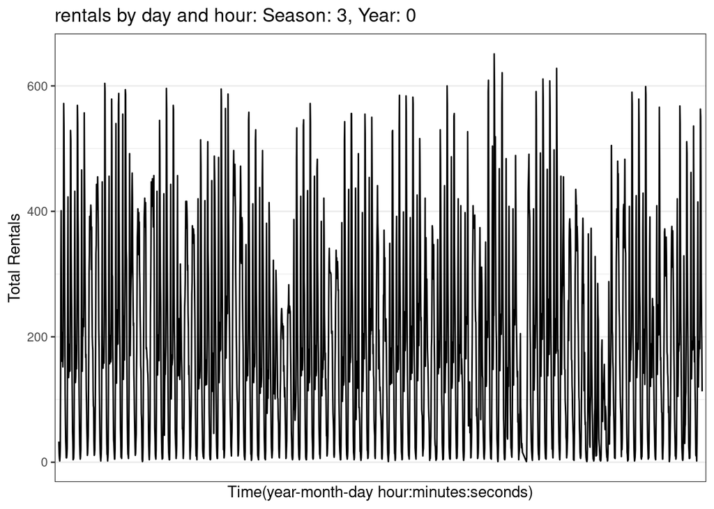

```r
# I wanted to show all of the data for each day and hour for a given
# season; otherwise, showing all would be messy. To make that work
# I made a concatenation of the date and the hour fields in the dataframe
mySeason<-3
myYear<-0
bikeByDayAndHour$newTime <- chron(dates=as.character(bikeByDayAndHour$dteday),
                                  times=paste0(bikeByDayAndHour$hr,":00:00"),
                                  format=c("y-m-d", "h:m:s"))
ggplot(data=subset(bikeByDayAndHour[which(bikeByDayAndHour$season==mySeason),], yr==myYear),
       aes(x=newTime, y=cnt)) +
  geom_line() +
  labs(title=paste0("rentals by day and hour: Season: ",mySeason,", Year: ", myYear),
       x="Time(year-month-day hour:minutes:seconds)",
       y="Total Rentals") +
  scale_x_discrete() +
  theme_bw()
```

## Forest

```r
forestData<-read.csv("data/forestFire/forestfires.csv")
```

## Facebook

```r
facebook<-read.csv("data/facebook/dataset_Facebook.csv", sep=";")
```

Here, I’ll go through code that implements a simplistic (Generalized) Linear model. The model will claim that, on each separate day, there’s a linear dependence of likes on the time of day you post. The general question would regard when the best time+day to post something is.

R users have a strong aversion to “for” loops, and use “apply” functions and matrix operations instead. “For” loops are slower in R, with applies being faster, and matrix operations (i.e. vectorized code) being the fastest.

```
##
## Call:  glm(formula = theseLikes ~ as.factor(isPaid) + theseHours, data = subsetData)
##
## Coefficients:
##        (Intercept)  as.factor(isPaid)1          theseHours
##            308.833            -100.279              -5.542
##
## Degrees of Freedom: 70 Total (i.e. Null);  68 Residual
##   (1 observation deleted due to missingness)
## Null Deviance:       4321000
## Residual Deviance: 4109000   AIC: 988.1
##
## Call:  glm(formula = theseLikes ~ as.factor(isPaid) + theseHours, data = subsetData)
##
## Coefficients:
##        (Intercept)  as.factor(isPaid)1          theseHours
##            165.055             358.965              -3.868
##
## Degrees of Freedom: 63 Total (i.e. Null);  61 Residual
## Null Deviance:       28140000
## Residual Deviance: 26390000  AIC: 1017
##
## Call:  glm(formula = theseLikes ~ as.factor(isPaid) + theseHours, data = subsetData)
##
## Coefficients:
##        (Intercept)  as.factor(isPaid)1          theseHours
##              92.34              111.78                5.43
##
## Degrees of Freedom: 65 Total (i.e. Null);  63 Residual
## Null Deviance:       3484000
## Residual Deviance: 3298000   AIC: 909.4
##
## Call:  glm(formula = theseLikes ~ as.factor(isPaid) + theseHours, data = subsetData)
##
## Coefficients:
##        (Intercept)  as.factor(isPaid)1          theseHours
##              73.34              152.16               13.91
##
## Degrees of Freedom: 67 Total (i.e. Null);  65 Residual
## Null Deviance:       8355000
```

[output cut: 17 more lines]

```
##
## Degrees of Freedom: 79 Total (i.e. Null);  77 Residual
##   (1 observation deleted due to missingness)
## Null Deviance:       1802000
## Residual Deviance: 1688000   AIC: 1032
##
## Call:  glm(formula = theseLikes ~ as.factor(isPaid) + theseHours, data = subsetData)
##
## Coefficients:
##        (Intercept)  as.factor(isPaid)1          theseHours
##            188.683             -11.677              -1.672
##
## Degrees of Freedom: 66 Total (i.e. Null);  64 Residual
## Null Deviance:       3461000
## Residual Deviance: 3456000   AIC: 925.1
```

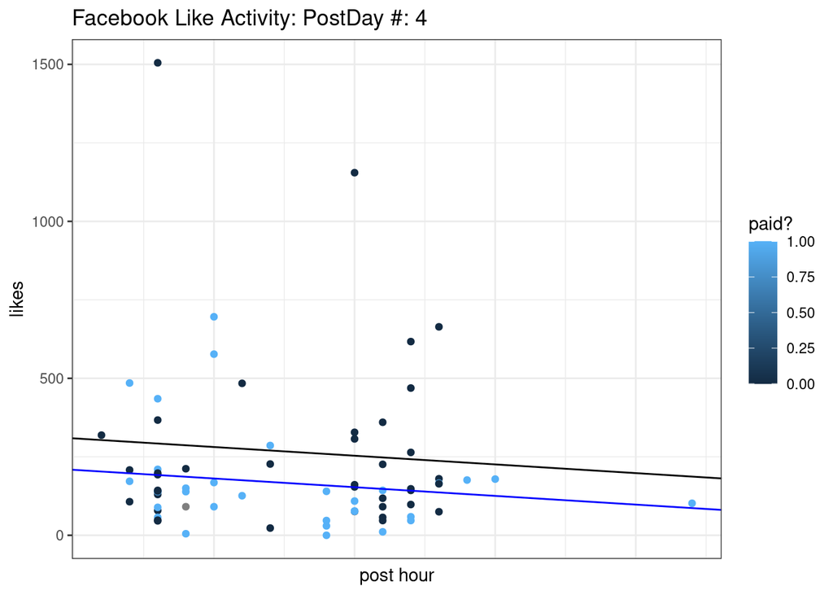

[figure not shown]

[figure not shown]

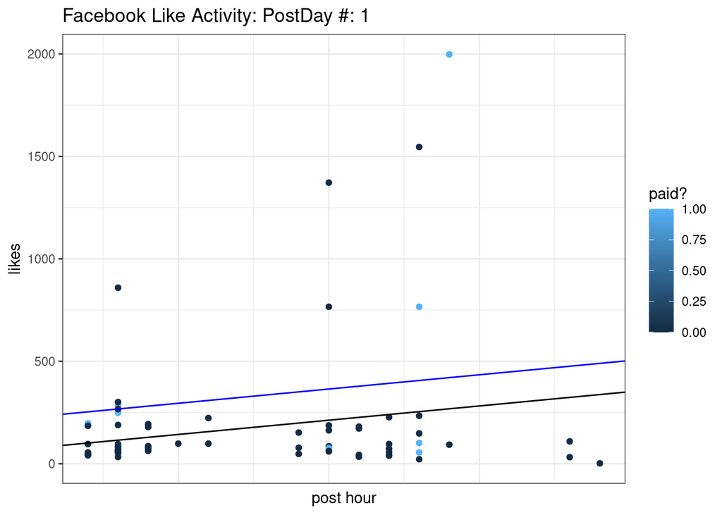

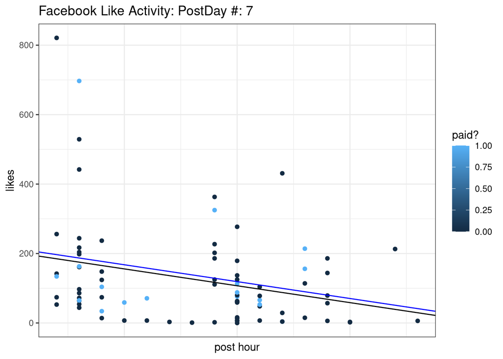

[figure not shown]

[figure not shown]

```r
# ggplot doesn't like having the periods in the x,y aesthetic
# I think ggplot tries to find an object Post.Hour...
colnames(facebook)[which(colnames(facebook)=="Post.Hour")]<-"PostHour"
colnames(facebook)[which(colnames(facebook)=="Post.Weekday")]<-"PostWeekday"
lapply(unique(facebook$PostWeekday), function(x){
  # building simple linear models with R.
  # Something we could ask of the facebook data could be
  # "When is the best day to post? Best Hour? Best Day and hour?"
  subsetData = facebook[which(facebook$PostWeekday==x),]
  theseLikes = subsetData$like
  isPaid = subsetData$Paid
  theseHours = subsetData$PostHour
  # extracting slopes, intercepts of model
  # both for paid and unpaid
  m1 = glm(theseLikes ~ as.factor(isPaid) + theseHours, data=subsetData)
  print(m1)
  thisIntercept = m1$coefficients[[1]]
  paidCoef = m1$coefficients[[2]]
  h = m1$coefficients[[3]]
  ggplot(subsetData, aes(x=PostHour, y=like, col=Paid)) +
  geom_point() +
  # fit the model
  geom_abline(slope = h, intercept=(thisIntercept+paidCoef), color="blue") +
    geom_abline(slope=h, intercept=thisIntercept, color="black")+
  theme_bw() +
  theme(axis.text.x=element_blank(), axis.ticks.x=element_blank()) +
  labs(title=paste0("Facebook Like Activity: PostDay #: ",x),
       x="post hour", y="likes", col="paid?")
})
```

These models aren’t necessarily good by any means, but are meant as a way to show how one can do this sort of thing in R, moreso with an automated mindset. Things we’d want to inspect to evaluate a model’s performance is, for example, the model’s AIC. AIC is used as a metric to compare two model; lower AIC relative to another’s is the goal. However, AIC is used as a relative metric, so if you had a bunch of bad models, picking the lowest AIC isn’t a surefire way standalone, but there are other methods that will probably be mentioned later in class.